بسمه تعالی

## Statistical Calculations

### Author Amirhossein Khadivi Supervisor Dr. Mohammad Kazemi Department of Statistics, University of Guilan

1- بسته نرم افزاری map را نصب و فراخوانی کنید و با استفاده از آن نقشه ایران را خروجی بگیرید.

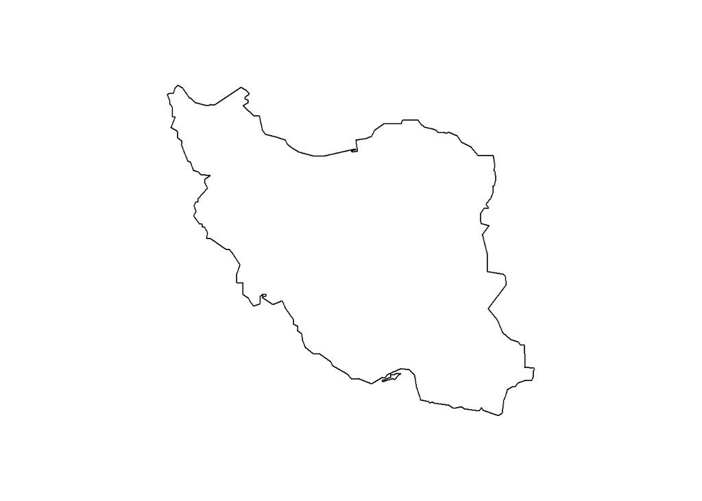

```r
# install.packages('maps')
library(maps)
map('world','iran')
```

2-طول وتر یک مثلث قائم الزاویه با اضلاع کناری به طول 5 و 7 را به کمک ماشین حساب کرده و حال میخواهیم آن را با R حساب کرده و نتایج را مقایسه کنیم.

```r
mh <- 8.602325267

a <- 7
b <- 5
c <- sqrt((a^2) + (b^2))
c
```

```
## [1] 8.602325
```

```r
mh == c
```

```
## [1] FALSE
```

مشاهده می شود که نتایج تقریبا یکسان و اختلاف اندک آنها نیز به دلیل وجود خطا در روش های عددی است.

4,3- می خواهیم ریشه های مختلط معادله درجه دوم x^2 - x + 1 = 0 را در R محاسبه کنیم و نتیجه را با جواب دستور polyroot که یک تابع برای محاسبه عددی ریشه های معادلات است مقایسه کنیم.

```r
a <- 1
b <- -1
c <- 1

delta <- (b^2) - (4*a*c)
d <- delta/(-1)
sqrt(d)
```

```
## [1] 1.732051
```

```r
deltam <- 1.732051i
x1 <- (-b + deltam)/(2*a)
x2 <- (-b - deltam)/(2*a)
print(paste('x1 : ',x1))
```

```
## [1] "x1 :  0.5+0.8660255i"
```

```r
print(paste('x2 : ',x2))
```

```
## [1] "x2 :  0.5-0.8660255i"
```

```r
x <- c(x1,x2)

y <- polyroot(c(1,-1,1))
print(y)
```

```
## [1] 0.5+0.8660254i 0.5-0.8660254i
```

```r
x == y
```

```
## [1] FALSE FALSE
```

مشاهده می شود که نتایج تقریبا یکسان هستند و اختلاف اندک آنها هم به دلیل خطای محاسباتی است.

5- میدانیم که مقدار cos(2arctan(x)) به ازای x=1 برابر صفر است. حال میخواهیم ببینیم که جواب در R که از روش های عددی برای محاسبه این عبارات استفاده میکند چقدر است.

```r
x <- 0
y <- cos(2*atan(1))
y
```

```
## [1] 6.123032e-17
```

```r
x == y
```

```
## [1] FALSE
```

مشاهده می شود که جواب صفر نشده ولی عددی بسیار کوچک و نزدیک به صفر است.  
6- می خواهیم تفاوت میان عملگرهای منطقی تکی(&,|)عملگرهای منطقی دوتایی(&&,||) را بررسی کنیم.

```r
x <- c(2<3,2!=2,2 != 2,2 <= 3)
y <- c(T,(3^2)==(2^3),F,1==1.0001)

x&y
```

```
## [1]  TRUE FALSE FALSE FALSE
```

```r
x&&y
```

```
## [1] TRUE
```

```r
x|y
```

```
## [1]  TRUE FALSE FALSE  TRUE
```

```r
x||y
```

```
## [1] TRUE
```

همانطور که مشاهده می شود عملگرهای منطقی تکی تمام درایه های نظیر به نظیر دو بردار را مقایسه می کنند ، ولی عملگرهای منطقی دوتایی فقط درایه اول نظیر به نظیر دو بردار را مقایسه می کنند.

7- مقدار توابع چگالی احتمال توزیع های نرمال استاندارد و t-استیودنت با درجه آزادی 5 در نقطه صفر را محاسبه می کنیم.

```r
x <- dnorm(0)
y <- dt(0,5)
print(paste('X~N(0,1)   f(0)=',x))
```

```
## [1] "X~N(0,1)   f(0)= 0.398942280401433"
```

```r
print(paste('X~t(5)     f(0)=',y))
```

```
## [1] "X~t(5)     f(0)= 0.379606689822494"
```

```r
print(paste('Distance = ',abs(x-y)))
```

```
## [1] "Distance =  0.0193355905789382"
```

مشاهده می شود که دو عدد نزدیک به هم هستند ، و هرچه درجه آزادی توزیع t بیشتر شود این اختلاف کمتر میشود. اگر درجه آزادی توزیع t به بی نهایت میل کند این اختلاف به لحاظ حدی صفر خواهد بود. (طبق قضیه حد مرکزی)  
حال برای درک بهتر موضوع از نمودار استفاده می کنیم.

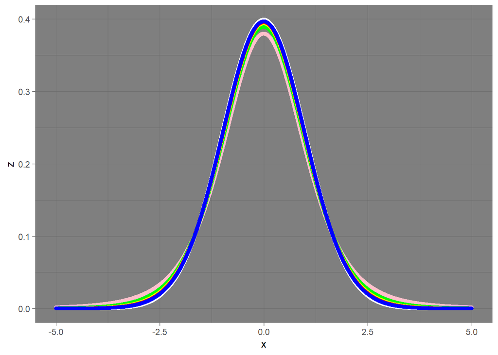

```r
library(ggplot2)
library(dplyr)

x <- seq(-5,5,0.001)

z <- dnorm(x)
t1 <- dt(x,5)
t2 <- dt(x,10)
t3 <- dt(x,20)
t4 <- dt(x,30)
t5 <- dt(x,40)

data <- data.frame(x,z,t1,t2,t3,t4,t5)
d <- cbind(z,t1,t2,t3,t4,t5)
x1 <- 'N(0,1)' ; x2 <- 't(5)' ; x3 <- 't(10)' ; x4 <- 't(20)' ; x5 <- 't(30)' ; x6 <- 't(40)'
f <- function(x){
  sample(x,(length(d)/6),replace = T)
}
d1 <- cbind(f(x1),f(x2),f(x3),f(x4),f(x5),f(x6))
d2 <- as.factor(d1)
data2 <- data.frame(d,d2)
data %>% ggplot() + geom_point(aes(x=x,y=z),color = 'white') + geom_point(aes(x=x,y=t1),color =         'pink') + geom_point(aes(x=x,y=t2),color = 'green') + geom_point(aes(x=x,y=t3),color='yellow')       +  geom_point(aes(x=x,y=t4),color='red') + geom_point(aes(x=x,y=t5),color='blue') +
     theme_dark()
```

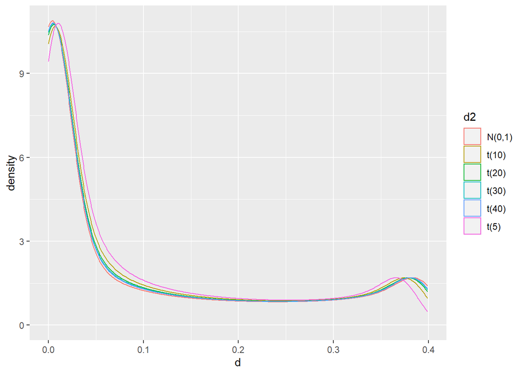

```r
data2 %>% ggplot() + geom_density(aes(x=d,col = d2))
```

8- چندک 2.5 و 97.5 توزیع کوشی استاندارد را محاسبه می کنیم.

```r
qcauchy(c(0.025 , 0.975),location = 0 , scale = 1)
```

```
## [1] -12.7062  12.7062
```

مشاهده می شود که دو نقطه قرینه یکدیگر هستند که به دلیل متقارن بودن این توزیع هست.

حال میخواهیم متقارن بودن توزیع کوشی را در همین فاصله روی نمودار نشان دهیم.

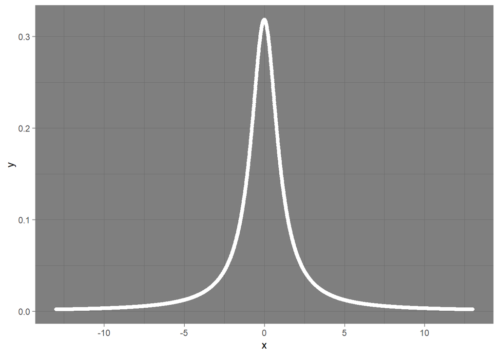

```r
library(ggplot2)
library(dplyr)
x <- seq(-13,13,0.01)
y <- dcauchy(x,0,1)
data <- data.frame(x,y)
data %>% ggplot(aes(x=x,y=y)) + geom_point(color = 'white') + theme_dark()
```